# Historical snowpack

Author

Roland Knapp

This file creates a dataset of the annual snowpack in Dana Meadows, Yosemite National Park. The data is from the Dana Meadows snow course (snow course number = DAN), and the annual 01-April data for the period 1927-to-present is downloaded from the California Data Exchange center using this [link](http://cdec.water.ca.gov/cgi-progs/snowQuery?course_num=dan&month=April&start_date=&end_date=&csv_mode=Y&data_wish=Retrieve+Data). Save the data displayed in browser window (right-click > Save Page As…) and don’t add a file extension.

```r
library(tidyverse)
library(lubridate)
```

### Create dataset

Note that the data are in inches.

```r
snowpack <- read_csv("snowQuery", na = "--") %>%
  mutate(Adjusted = ifelse(is.na(Adjusted), Water, Adjusted),
         year = year(my(Date)),
         date_measure = ymd(dmy(Meas.Date))) %>%
  rename(snow_depth = Depth,
         swe = Water,
         swe_adj = Adjusted) %>%
  select(year, date_measure, snow_depth, swe, swe_adj)
```

- year: year in which 01-April snow course measurement was made
- date_measure: date on with 01-April snow course measurement was made
- snow_depth: snow depth from snow course, in inches
- swe: snow water equivalent from snow course
- swe_adj: snow water equivalent from snow course, adjusted by jurisdiction that collected data
- swe_pave: adjusted snow water equivalent, as a percentage of the average

### Add current-year snowpack from snow pillow

To include current snowpack measured prior to 01-April, use daily data from DAN [snow pillow](https://cdec.water.ca.gov/dynamicapp/QueryDaily).

```r
snow_current <- tibble("year" = 2023, date_measure = ymd("2023-03-12"), snow_depth = 176, swe = 47.72, swe_adj = 57.44)

snowpack <- bind_rows(snowpack, snow_current)
```

### Calculate snowpack as percent of long-term average

```r
swe_ave <- snowpack %>%
  filter(year != 2023) %>%
  summarise(swe_mean = mean(swe_adj))

snowpack <- snowpack %>%
  mutate(swe_pave = (swe_adj / swe_ave$swe_mean) * 100)
```

### Plot data

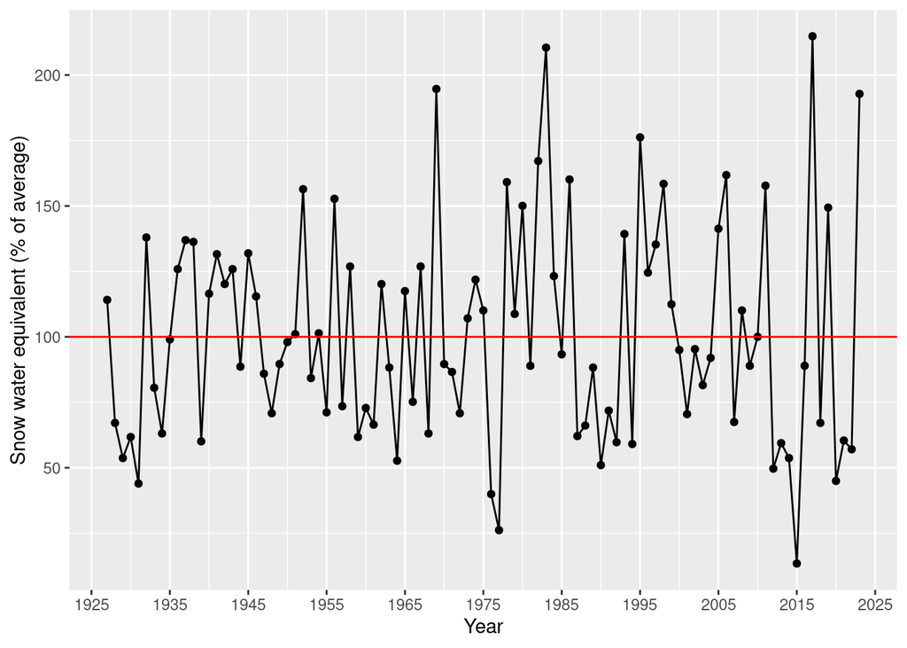

```r
# Plot of snowpack from 1927 to current year
snowpack %>%
  ggplot(aes(x = year, y = swe_pave)) +
  geom_line() +
  geom_point() +
  scale_x_continuous(breaks = seq(1925, 2025, 10)) +
  labs(x = "Year", y = "Snow water equivalent (% of average)") +
  geom_hline(yintercept = 100, color = "red")
```

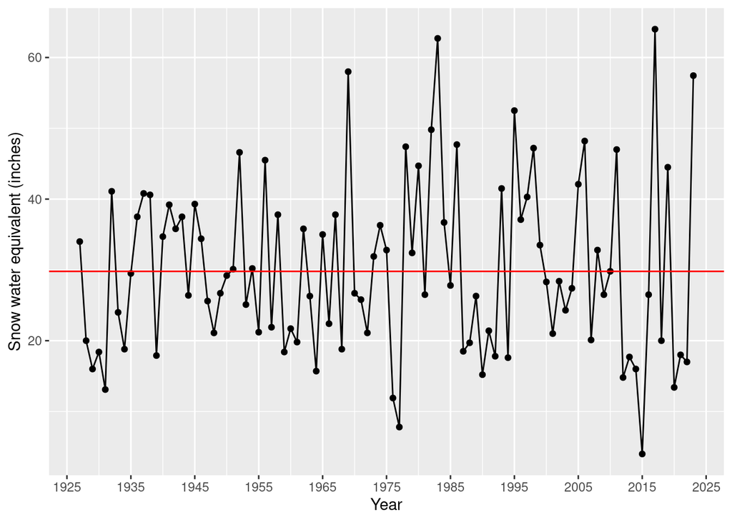

```r
snowpack %>%
  ggplot(aes(x = year, y = swe_adj)) +
  geom_line() +
  geom_point() +
  scale_x_continuous(breaks = seq(1925, 2025, 10)) +
  labs(x = "Year", y = "Snow water equivalent (inches)") +
  geom_hline(yintercept = swe_ave$swe_mean, color = "red")
```

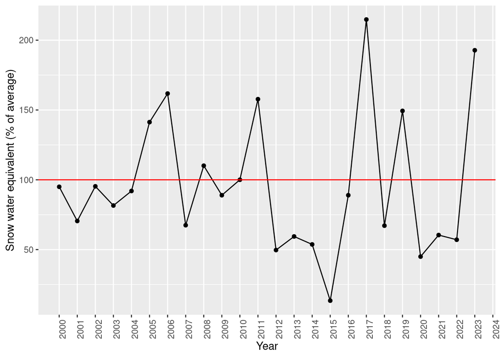

```r
# Plot of snowpack from 2000 to current year
snowpack %>%
  filter(year >= 2000) %>%
  ggplot(aes(x = year, y = swe_pave)) +
  geom_line() +
  geom_point() +
  scale_x_continuous(breaks = seq(2000, 2024, 1), minor_breaks = NULL) +
  labs(x = "Year", y = "Snow water equivalent (% of average)") +
  geom_hline(yintercept = 100, color = "red") +
  theme(axis.text.x = element_text(angle = 90))
```